# Introduction to Machine Learning - Part 2

Random Forest

Gladstone Bioinformatics Core

2026-01-06

# Introduction to Random Forest

## From Decision Trees to Random Forests

### What is a Decision Tree?

A decision tree makes predictions by learning simple decision rules from the data:

```
                    [Temperature > 37.5?]
                    /                    \
                  Yes                     No
                  /                        \
        [Has Cough?]                  [Loss of Smell?]
         /       \                      /         \
       Yes       No                   Yes          No
        |         |                    |            |
    Positive  Negative             Positive     Negative
```

### What is Random Forest?

Random Forest is an **ensemble method** that builds many decision trees and combines their predictions!

```
   Tree 1      Tree 2      Tree 3     ...    Tree N
     |           |           |                  |
  Positive   Negative    Positive           Positive
     \           |           /                  /
      \          |          /                  /
       ========= VOTE =======================
              POSITIVE (majority wins!)
```

### Why “Random”?

Two sources of randomness make trees diverse: 1. **Bootstrap sampling**: Each tree trained on random subset of data 2. **Feature sampling**: Each split considers random subset of features

This diversity reduces overfitting and improves predictions!

# Load Libraries and Data

```r
# Core libraries
library(tidyverse)
library(caret)
library(randomForest)
library(ggplot2)

# Set seed for reproducibility
set.seed(123)
```

```r
# Load the cleaned dataset from Part 1
covid_ml <- read.csv("data/covid_ml_clean.csv")

# Convert target to factor
covid_ml$covid19_test_results <- as.factor(covid_ml$covid19_test_results)

cat("Dataset dimensions:", dim(covid_ml), "\n")
```

```
## Dataset dimensions: 3045 19
```

# Prepare Data

## Train-Test Split

**Why split the data?**

- **Training set**: Used to train/fit the model
- **Test set**: Used to evaluate model performance on unseen data

This helps us estimate how well our model will generalize to new data!

```r
# Split data: 70% training, 30% testing
train_index <- createDataPartition(covid_ml$covid19_test_results,
                                   p = 0.7,
                                   list = FALSE)

train_data <- covid_ml[train_index, ]
test_data <- covid_ml[-train_index, ]

cat("Training set size:", nrow(train_data), "\n")
```

```
## Training set size: 2132
```

```r
cat("Test set size:", nrow(test_data), "\n")
```

```
## Test set size: 913
```

**Note:** Unlike some other algorithms, we don’t need to scale features for Random Forest! Tree-based methods are invariant to monotonic transformations of features.

# Train a Simple Random Forest

Let’s start with a basic Random Forest to understand the output:

```r
# Train a simple random forest
rf_simple <- randomForest(
  covid19_test_results ~ .,  # Predict target using all features
  data = train_data,
  ntree = 100,               # Number of trees
  importance = TRUE          # Calculate variable importance
)

# View the model summary
print(rf_simple)
```

```
##
## Call:
##  randomForest(formula = covid19_test_results ~ ., data = train_data,      ntree = 100, importance = TRUE)
##                Type of random forest: classification
##                      Number of trees: 100
## No. of variables tried at each split: 4
##
##         OOB estimate of  error rate: 2.2%
## Confusion matrix:
##          Negative Positive  class.error
## Negative     2082        2 0.0009596929
## Positive       45        3 0.9375000000
```

## Understanding the Output

```r
# OOB (Out-of-Bag) Error
cat("OUT-OF-BAG (OOB) ERROR EXPLAINED:\n")
```

```
## OUT-OF-BAG (OOB) ERROR EXPLAINED:
```

```r
cat("================================\n")
cat("Random Forest uses bootstrap sampling, so ~37% of data is left out for each tree.\n")
```

```
## Random Forest uses bootstrap sampling, so ~37% of data is left out for each tree.
```

```r
cat("These 'out-of-bag' samples are used to estimate error without needing a separate validation set!\n\n")
```

```
## These 'out-of-bag' samples are used to estimate error without needing a separate validation set!
```

```r
cat("OOB Error Rate:", round(rf_simple$err.rate[nrow(rf_simple$err.rate), "OOB"] * 100, 2), "%\n")
```

```
## OOB Error Rate: 2.2 %
```

## Plot Error vs Number of Trees

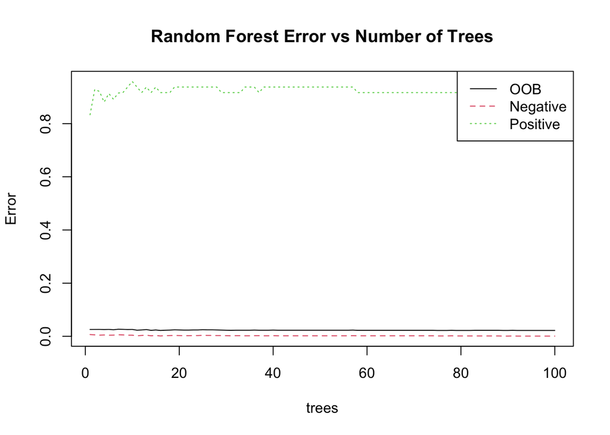

```r
# Plot OOB error as more trees are added
plot(rf_simple, main = "Random Forest Error vs Number of Trees")
legend("topright",
       legend = colnames(rf_simple$err.rate),
       col = 1:3,
       lty = 1:3)
```

The error typically stabilizes after a certain number of trees. More trees rarely hurt (except for computation time)!

# Tune Random Forest with Cross-Validation

## Key Hyperparameters

- **ntree**: Number of trees (more is usually better, but diminishing returns)
- **mtry**: Number of features to consider at each split
  - Default for classification: sqrt(number of features)

```r
# Set up cross-validation
cv_control <- trainControl(
  method = "cv",
  number = 10,
  classProbs = TRUE,
  summaryFunction = twoClassSummary
)

# Grid of mtry values to try
mtry_grid <- expand.grid(mtry = c(2, 4, 6, 8, 10))

# Train with cross-validation
rf_cv <- train(
  covid19_test_results ~ .,
  data = train_data,
  method = "rf",
  trControl = cv_control,
  tuneGrid = mtry_grid,
  ntree = 200,
  metric = "ROC"
)

# View results
rf_cv
```

```
## Random Forest
##
## 2132 samples
##   18 predictor
##    2 classes: 'Negative', 'Positive'
##
## No pre-processing
## Resampling: Cross-Validated (10 fold)
## Summary of sample sizes: 1918, 1919, 1919, 1918, 1919, 1920, ...
## Resampling results across tuning parameters:
##
##   mtry  ROC        Sens       Spec
##    2    0.6894564  1.0000000  0.00
##    4    0.6912950  0.9990385  0.00
##    6    0.6859568  0.9971154  0.02
##    8    0.6789073  0.9961538  0.04
##   10    0.6696294  0.9956777  0.08
##
## ROC was used to select the optimal model using the largest value.
## The final value used for the model was mtry = 4.
```

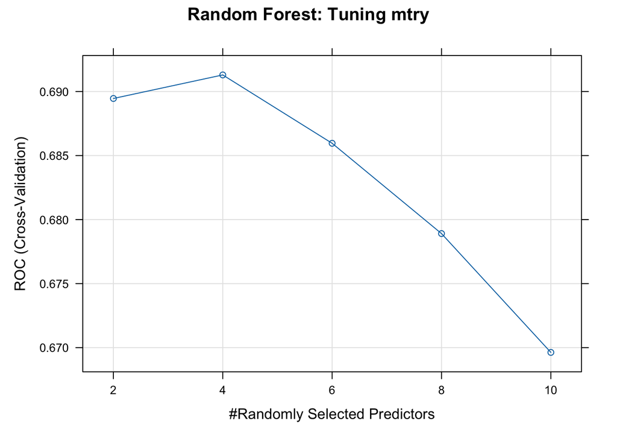

```r
# Plot mtry vs performance
plot(rf_cv, main = "Random Forest: Tuning mtry")
```

```r
cat("Best mtry:", rf_cv$bestTune$mtry, "\n")
```

```
## Best mtry: 4
```

# Variable Importance

One of the best features of Random Forest is built-in variable importance!

## Mean Decrease Gini

This measures how much each variable contributes to the purity of nodes in the trees. Higher values = more important.

```r
# Get variable importance from our simple RF model
importance_df <- as.data.frame(importance(rf_simple))
importance_df$Variable <- rownames(importance_df)

# View importance metrics
head(importance_df)
```

```
##                                 Negative   Positive MeanDecreaseAccuracy
## temperature                    0.7791595  0.7756247            0.9944406
## high_risk_exposure_occupation -1.4560971  0.2196700           -1.4005090
## high_risk_interactions        -0.5752342  1.7303118           -0.1726880
## labored_respiration           -0.4341303 -1.0050378           -0.8034755
## rhonchi                        1.5778529  1.0050378            1.7184456
## cough                          4.7018134  1.6976468            5.0452009
##                               MeanDecreaseGini                      Variable
## temperature                          9.8817093                   temperature
## high_risk_exposure_occupation        2.1012758 high_risk_exposure_occupation
## high_risk_interactions               1.9300832        high_risk_interactions
## labored_respiration                  0.7987589           labored_respiration
## rhonchi                              0.5831962                       rhonchi
## cough                                2.7424224                         cough
```

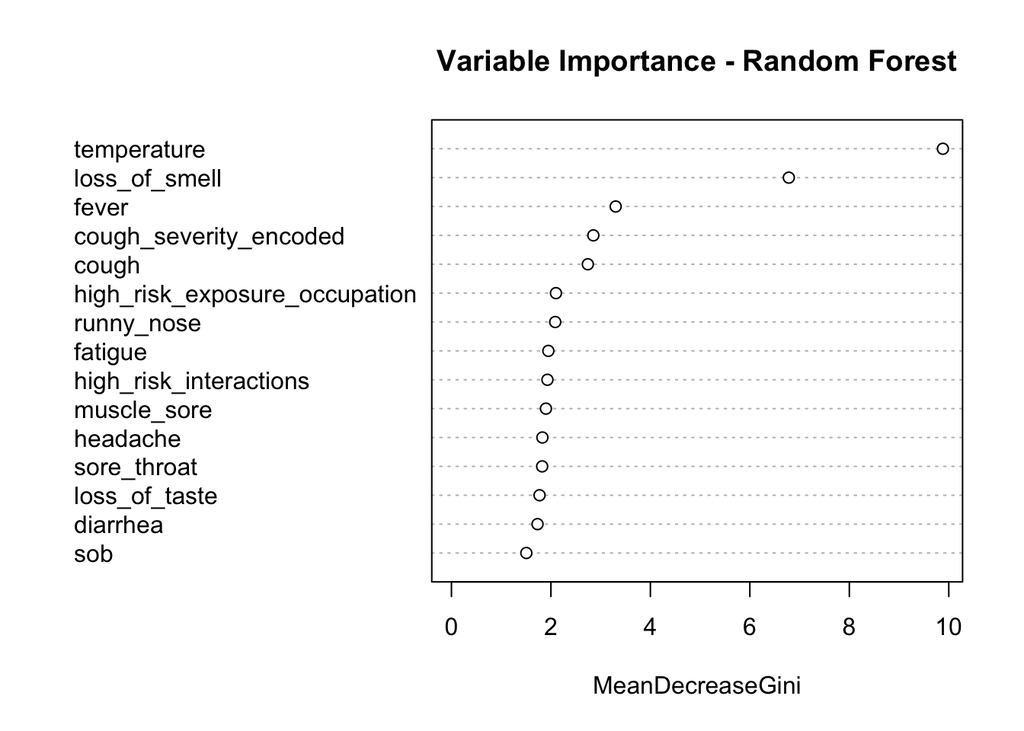

```r
# Plot variable importance
varImpPlot(rf_simple,
           type = 2,  # Mean Decrease Gini
           main = "Variable Importance - Random Forest",
           n.var = 15)
```

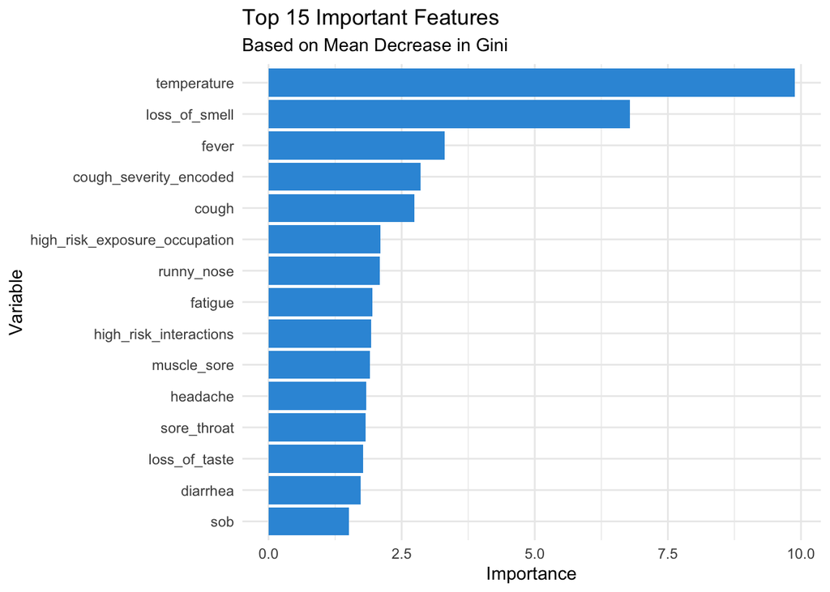

```r
# Create a nicer ggplot version
importance_df %>%
  arrange(desc(MeanDecreaseGini)) %>%
  head(15) %>%
  ggplot(aes(x = reorder(Variable, MeanDecreaseGini),
             y = MeanDecreaseGini)) +
  geom_bar(stat = "identity", fill = "#3498db") +
  coord_flip() +
  labs(title = "Top 15 Important Features",
       subtitle = "Based on Mean Decrease in Gini",
       x = "Variable",
       y = "Importance") +
  theme_minimal()
```

# Make Predictions

```r
# Predict on test set
rf_predictions <- predict(rf_cv, newdata = test_data)

# View predictions
head(rf_predictions)
```

```
## [1] Negative Negative Negative Negative Negative Negative
## Levels: Negative Positive
```

```r
# Get prediction probabilities
rf_proba <- predict(rf_cv, newdata = test_data, type = "prob")
head(rf_proba)
```

```
##    Negative Positive
## 3     0.915    0.085
## 6     1.000    0.000
## 15    1.000    0.000
## 16    1.000    0.000
## 20    1.000    0.000
## 23    1.000    0.000
```

# Evaluate Model Performance

## Confusion Matrix

A confusion matrix shows how well the model classified each class:

```
                    Predicted
                 Negative  Positive
Actual Negative    TN        FP
       Positive    FN        TP

TN = True Negative  (correctly predicted negative)
TP = True Positive  (correctly predicted positive)
FN = False Negative (missed positive case)
FP = False Positive (false alarm)
```

```r
# Create confusion matrix
cm_rf <- confusionMatrix(rf_predictions, test_data$covid19_test_results,
                         positive = "Positive")
print(cm_rf)
```

```
## Confusion Matrix and Statistics
##
##           Reference
## Prediction Negative Positive
##   Negative      893       19
##   Positive        0        1
##
##                Accuracy : 0.9792
##                  95% CI : (0.9677, 0.9874)
##     No Information Rate : 0.9781
##     P-Value [Acc > NIR] : 0.4693
##
##                   Kappa : 0.0933
##
##  Mcnemar's Test P-Value : 3.636e-05
##
##             Sensitivity : 0.050000
##             Specificity : 1.000000
##          Pos Pred Value : 1.000000
##          Neg Pred Value : 0.979167
##              Prevalence : 0.021906
##          Detection Rate : 0.001095
##    Detection Prevalence : 0.001095
##       Balanced Accuracy : 0.525000
##
##        'Positive' Class : Positive
##
```

## Understanding the Metrics

```r
# Extract key metrics
accuracy <- cm_rf$overall["Accuracy"]
sensitivity <- cm_rf$byClass["Sensitivity"]
specificity <- cm_rf$byClass["Specificity"]

cat("KEY METRICS:\n")
```

```
## KEY METRICS:
```

```r
cat("============\n")
cat("Accuracy:", round(accuracy * 100, 2), "%\n")
```

```
## Accuracy: 97.92 %
```

```r
cat("  - Overall correct predictions\n\n")
```

```
##   - Overall correct predictions
```

```r
cat("Sensitivity (Recall):", round(sensitivity * 100, 2), "%\n")
```

```
## Sensitivity (Recall): 5 %
```

```r
cat("  - Of all actual positives, how many did we catch?\n")
```

```
##   - Of all actual positives, how many did we catch?
```

```r
cat("  - Important when missing a positive case is costly\n\n")
```

```
##   - Important when missing a positive case is costly
```

```r
cat("Specificity:", round(specificity * 100, 2), "%\n")
```

```
## Specificity: 100 %
```

```r
cat("  - Of all actual negatives, how many did we correctly identify?\n")
```

```
##   - Of all actual negatives, how many did we correctly identify?
```

## Visualize Confusion Matrix

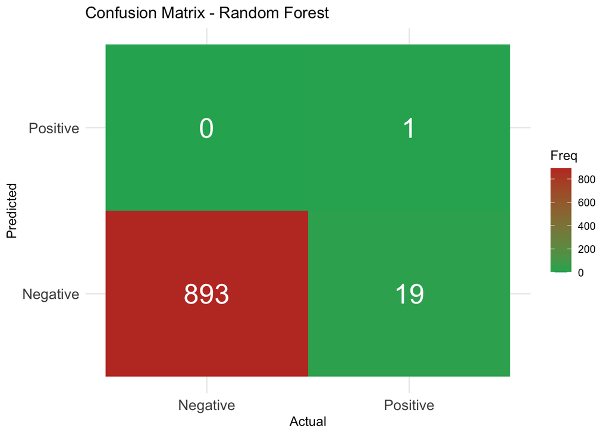

```r
# Convert confusion matrix to data frame for plotting
cm_df <- as.data.frame(cm_rf$table)

ggplot(cm_df, aes(x = Reference, y = Prediction, fill = Freq)) +
  geom_tile() +
  geom_text(aes(label = Freq), size = 8, color = "white") +
  scale_fill_gradient(low = "#27ae60", high = "#c0392b") +
  labs(title = "Confusion Matrix - Random Forest",
       x = "Actual",
       y = "Predicted") +
  theme_minimal() +
  theme(axis.text = element_text(size = 12))
```

# Summary

## What We Learned

1. ✅ **Random Forest** builds many decision trees and combines their predictions
2. ✅ **Bootstrap + feature sampling** creates diverse trees that reduce overfitting
3. ✅ **No scaling required** - trees are scale-invariant
4. ✅ **Variable importance** helps understand which features matter most
5. ✅ **OOB error** provides built-in validation estimate
6. ✅ **Cross-validation** helps tune hyperparameters like mtry

## When to Use Random Forest

- ✅ Mixed numeric and categorical features
- ✅ Want to understand feature importance
- ✅ Large datasets
- ✅ Don’t want to tune many hyperparameters
- ✅ Need a robust baseline model

## What’s Next?

In **Part 3**, we’ll explore **K-means clustering** - an unsupervised learning method for finding patterns without labels!